# PSL_9 Cyclical Trends and Volatility

## Part 1

the goal for the first portion of the assignment is to analyze and interpret time series data. we were assigned the visitors portion of the provided dataset.

A. Plot the time series. Can you identify seasonal fluctuations and/or a trend?

```r
library(fpp)
```

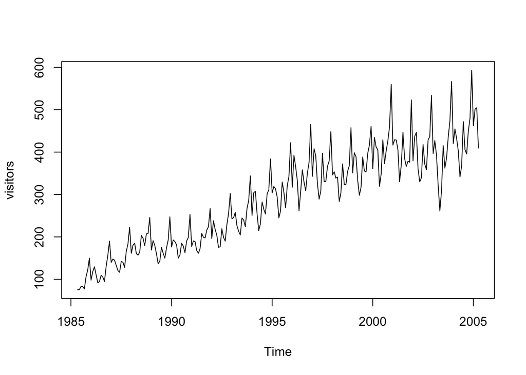

```r
data(books)
data(ukcars)
data(visitors)
plot(visitors, type="l")
```

Looking at the data above, there does appear to be cyclical trends every year. The visitors is continuously increasing and decreasing.

B. Calculating the trend-cycle and seasonal indices through classical decompression

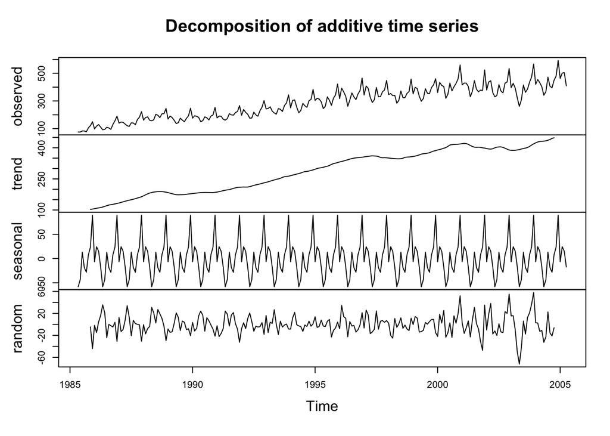

```r
fitd <- decompose(visitors)
plot(fitd)
```

C. Do the results support the graphical interpretation from part (a)? Trend shows consistent increase, seasonal shoes peaks and dips during seasons.

D.Compute and plot the seasonally adjusted data.

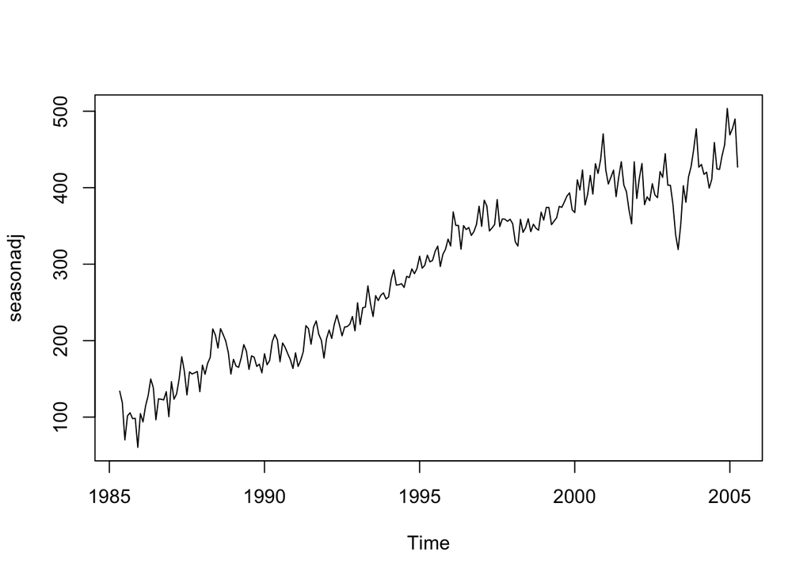

```r
seasonadj <- seasadj(fitd)
plot(seasonadj, type="l")
```

E. Change one observation to be an outlier (e.g., add 500 to one observation), and recompute the seasonally adjusted data. What is the effect of the outlier?

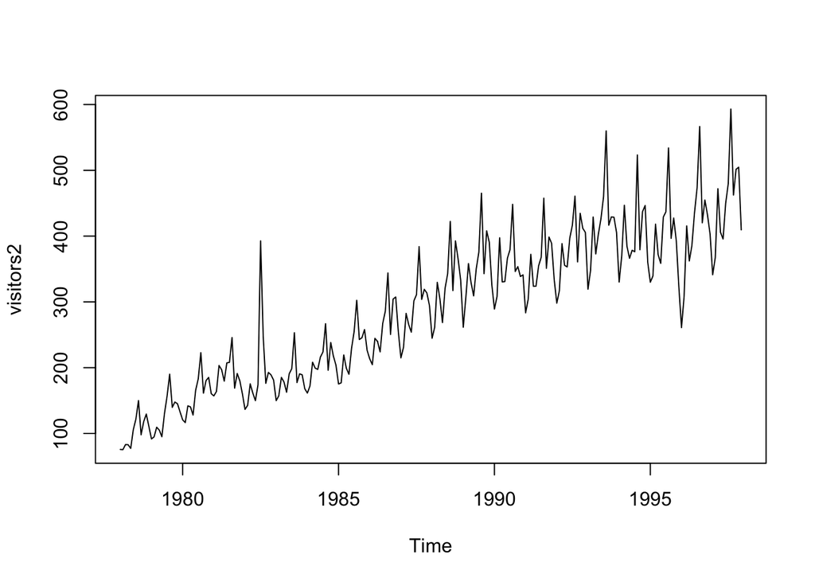

```r
visitors2 <- ts(c(visitors[1:54], visitors[55]+200, visitors[56:240]),start=c(1978,1),frequency = 12)
plot(visitors2, type="l")
```

Here I add 200 to the 55 visitor value to see if there is much change. The cyclical plot do no change but the outlier is apparent in the season adjusted data.

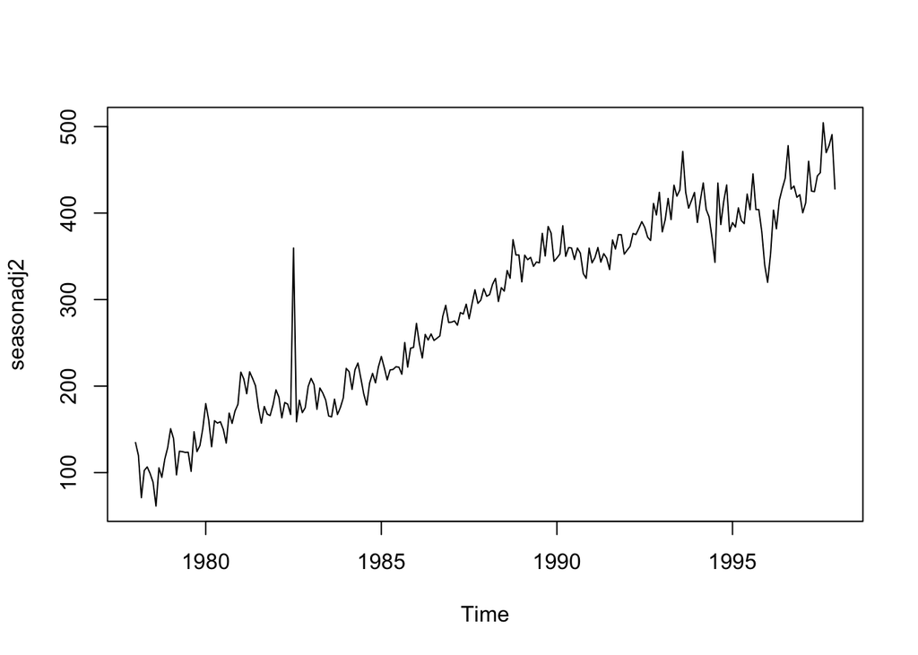

```r
fitd2 <- decompose(visitors2)
seasonadj2 <- seasadj(fitd2)
plot(seasonadj2, type="l")
```

F. Does it make any difference if the outlier is near the end rather than in the middle of the time series?

No in class we ran multiple different simulation and for each the outlier was still prominent regardless of position.

G.Use STL to decompose the series

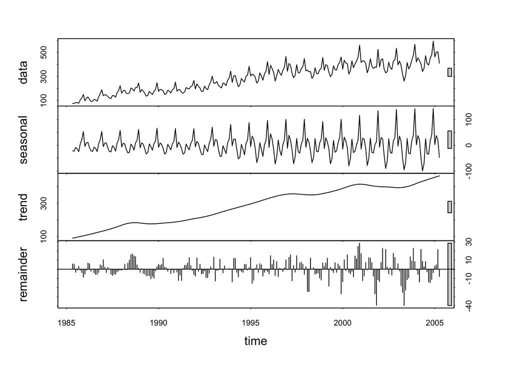

```r
fitvisitors <- stl(visitors, s.window = 5)
plot(fitvisitors)
```

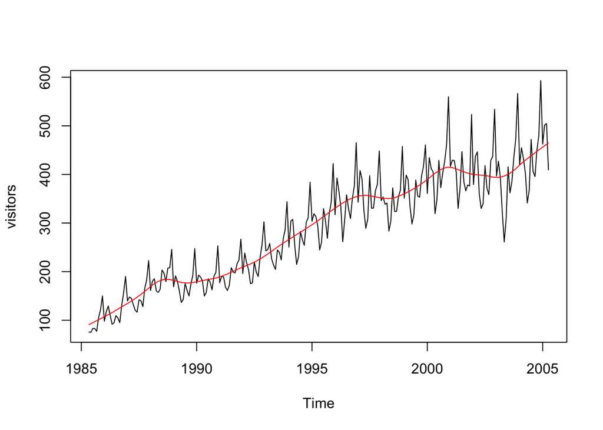

```r
plot(visitors)
lines(fitvisitors$time.series[,2],col="red",ylad="Trend")
```

## Part 2

We were each assigned stocks and asked to calculated the log return and measure volatility. I got PSXP, which stands for Phillips 66 Partners, which is an Oil company

First we grab the data from yahoo

```r
library(tseries)
PEPdata <- get.hist.quote('psxp',quote="Close")
```

```
## time series starts 2013-07-23
```

```r
length(PEPdata)
```

```
## [1] 753
```

Show the length of the dataset

Now we take the log of the dataset to get the log returns

```r
PEPret <- log(lag(PEPdata))-log(PEPdata)
PEPvol <- sd(PEPret) * sqrt(250) * 100
PEPvol
```

```
## [1] 37.34803
```

And now we calculate the non continuous volatility shown above. Did not print out the table because it was very long.

Below is a loop that creates a continuous lookback windown for the volatility measurement

```r
PEPVol <- function(d, logrets){
  var=0
  lam= 0
  varlist <- c()
  for(r in logrets){
    lam = lam*(1 - 1/d) + 1
    var = (1-1/lam)*var + (1/lam)*r^2
    varlist <- c(varlist,var)}
  sqrt(varlist)}
```

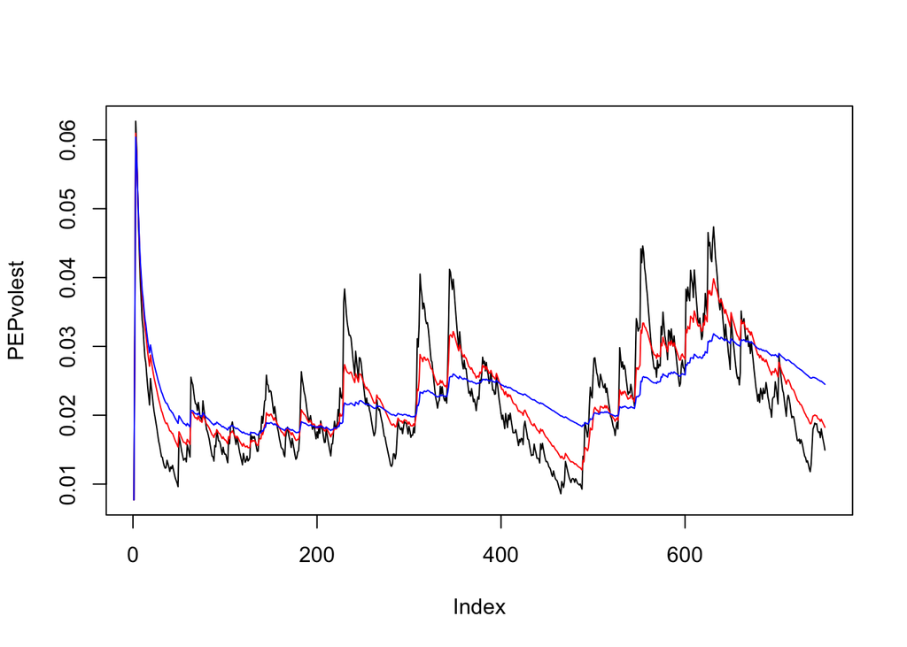

```r
PEPvolest <- PEPVol(10,PEPret)
PEPvolest2 <- PEPVol(30,PEPret)
PEPvolest3 <- PEPVol(100,PEPret)

plot(PEPvolest, type="l")
lines(PEPvolest2, type="l", col="red")
lines(PEPvolest3, type="l", col="blue")
```

Plotted all together

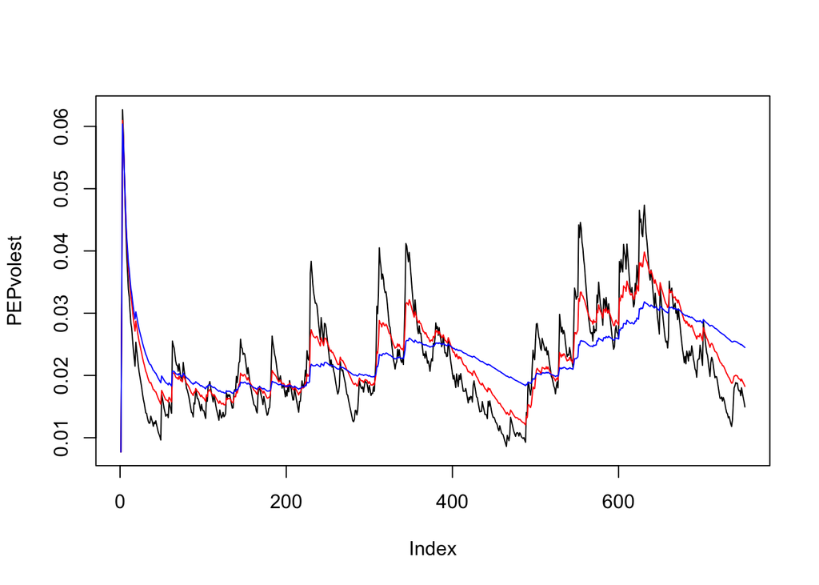

```r
plot(PEPvolest, type="l")
lines(PEPvolest2, type="l", col="red")
lines(PEPvolest3, type="l", col="blue")
```